# My visual data story

# When and How Do People Use Their Phones?

## 1. Some apps dominate People’s daily habits

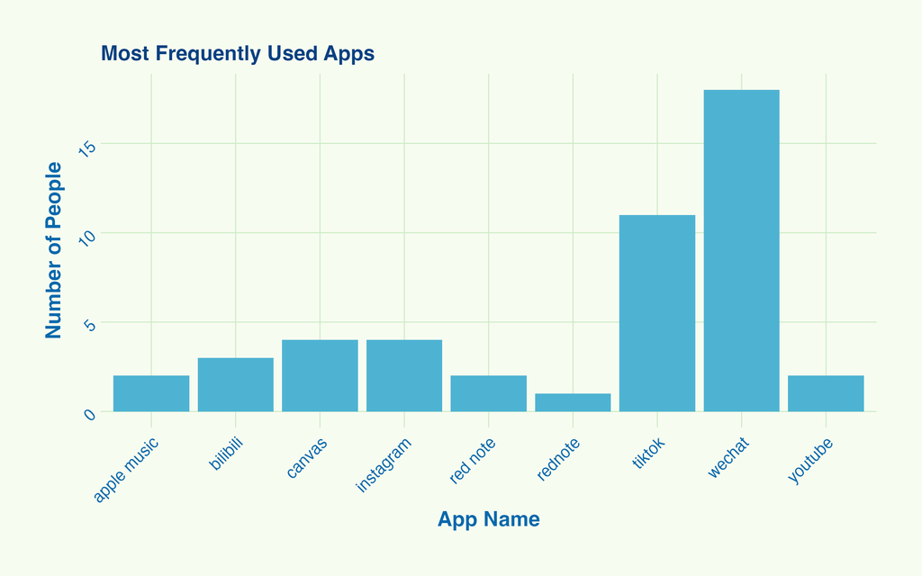

## 2. App usage patterns change across the day.

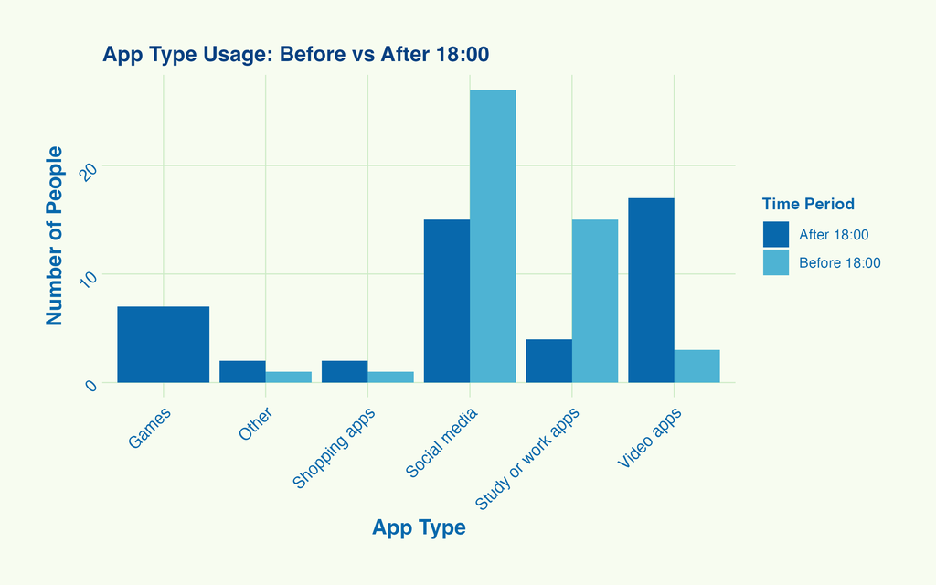

Before 6pm, students mostly used study/work apps and social media. After 6pm, video apps and games became more popular — suggesting a switch from study to entertainment.

## 3. Different apps have different usage.

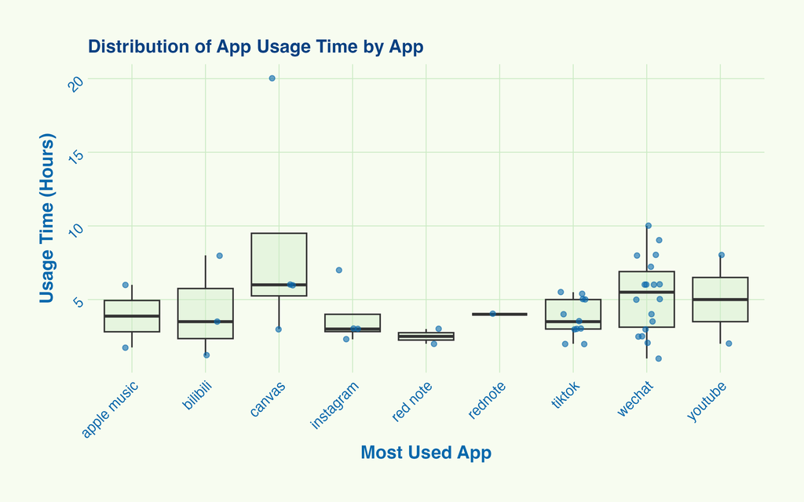

## 4. University users spend more time on study apps

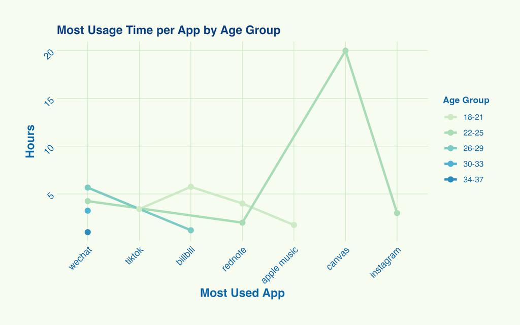

Age matters. Younger students tend to spend more time on study apps or entertainment or social apps, while older groups prefer communication or productive tools.

## 5. Submission times show usage behavior

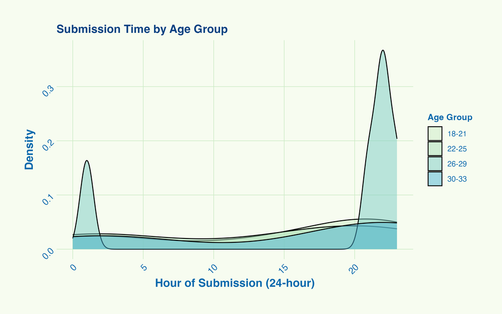

Submission times reflect participants’ behavior — some students submit late at night, others during the day, with patterns differing by age. This might also be because I always start doing my homework in the middle of the night, so I urge my friends who haven’t gone to sleep yet to help me complete my forms.

Why don’t people go to bed at dawn? I’m using canvas. What app are they using?

## 6. Watch it build up: Animated behavior by age group

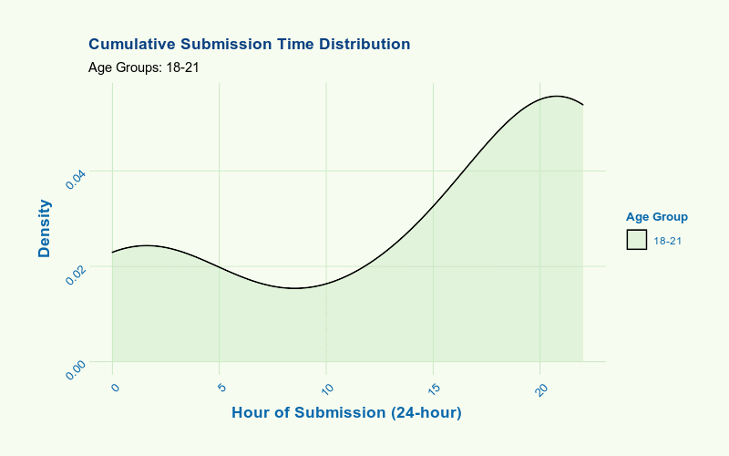

The distribution of form submission times by age group

This animation reveals, one by one, how each age group’s submission habits stack together — showing clear temporal patterns and potential lifestyle differences.